# Interactive COVID-19 Report

[output not shown]

[output not shown]

[output not shown]

[output not shown]

[output not shown]

[output not shown]

[output not shown]

[output not shown]

[output not shown]

[output not shown]

[output not shown]

[output not shown]

[figure not shown]

## A closer look at your area(s) of interest:

### Los Angeles County, CA

> As of yesterday, there has been a total of 1,024,592 cases of COVID-19 in Los Angeles County, California. This is a change of 9,529 (0.94%) new cases since the day prior. The 7 day moving average is currently 1.254e+04 new cases which is a -7.41% change since the day prior and -13.85% change since the week prior. The immediate trend is heading downward. Based on the addition of yesterday’s data, yesterday was not an inflection point (days since last inflection point: 4 –> 2021-01-15).

#### 7-day moving average of new cases in Los Angeles County (2020-01-26 to 2021-01-18)

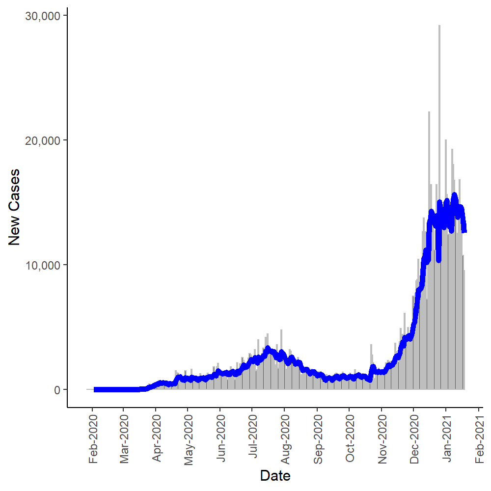

### New York City, NY

> As of yesterday, there has been a total of 536,287 cases of COVID-19 in New York City County, New York. This is a change of 6,453 (1.22%) new cases since the day prior. The 7 day moving average is currently 6,174 new cases which is a 1.53% change since the day prior and 3.37% change since the week prior. The immediate trend is heading upward. Based on the addition of yesterday’s data, yesterday was not an inflection point (days since last inflection point: 29 –> 2020-12-21).

#### 7-day moving average of new cases in New York City (2020-03-01 to 2021-01-18)

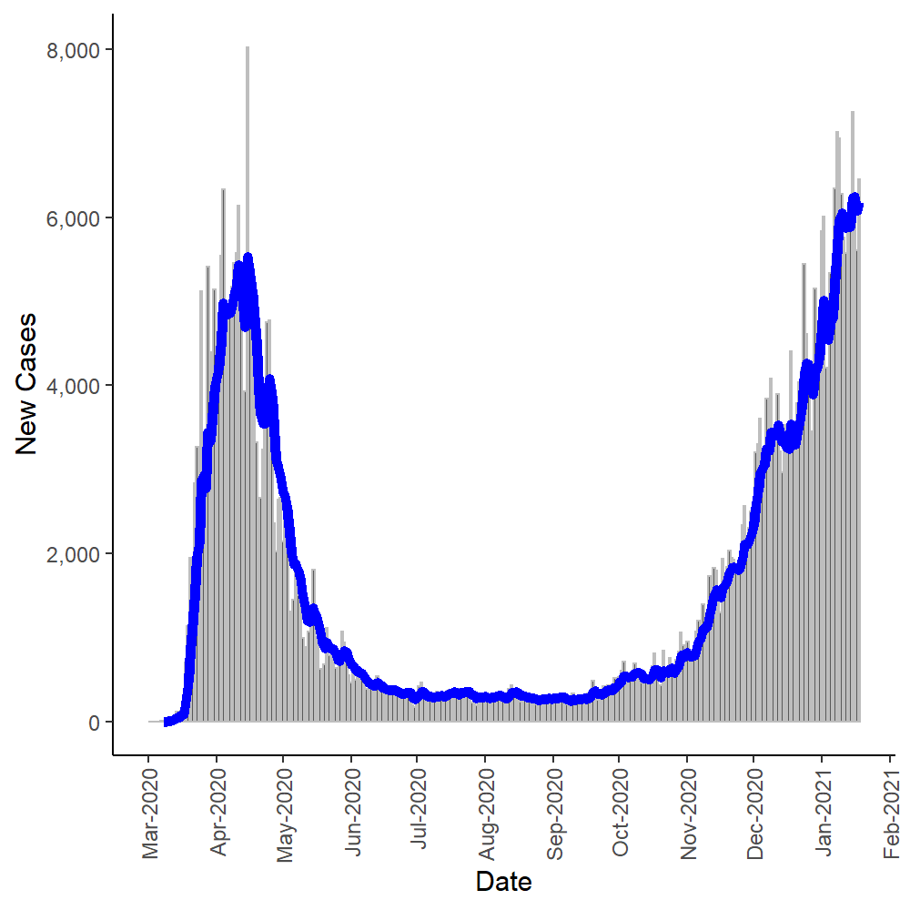

### Chicago (Cook County), IL

> As of yesterday, there has been a total of 434,341 cases of COVID-19 in Cook County, Illinois. This is a change of 1,252 (0.29%) new cases since the day prior. The 7 day moving average is currently 1,946 new cases which is a -10.62% change since the day prior and -14.98% change since the week prior. The immediate trend is heading downward. Based on the addition of yesterday’s data, yesterday was not an inflection point (days since last inflection point: 6 –> 2021-01-13).

#### 7-day moving average of new cases in Chicago (Cook County) (2020-01-24 to 2021-01-18)

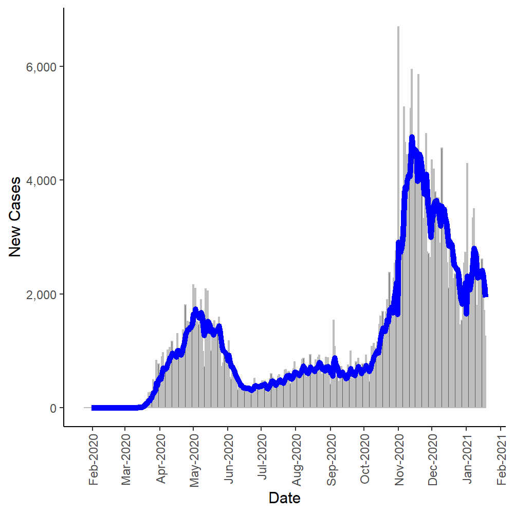

### Boston (Suffolk County), MA

> As of yesterday, there has been a total of 65,804 cases of COVID-19 in Suffolk County, Massachusetts. This is a change of 406 (0.62%) new cases since the day prior. The 7 day moving average is currently 575.8 new cases which is a -8.95% change since the day prior and -17.88% change since the week prior. The immediate trend is heading downward. Based on the addition of yesterday’s data, yesterday was not an inflection point (days since last inflection point: 5 –> 2021-01-14).

#### 7-day moving average of new cases in Boston (Suffolk County) (2020-09-13 to 2021-01-18)

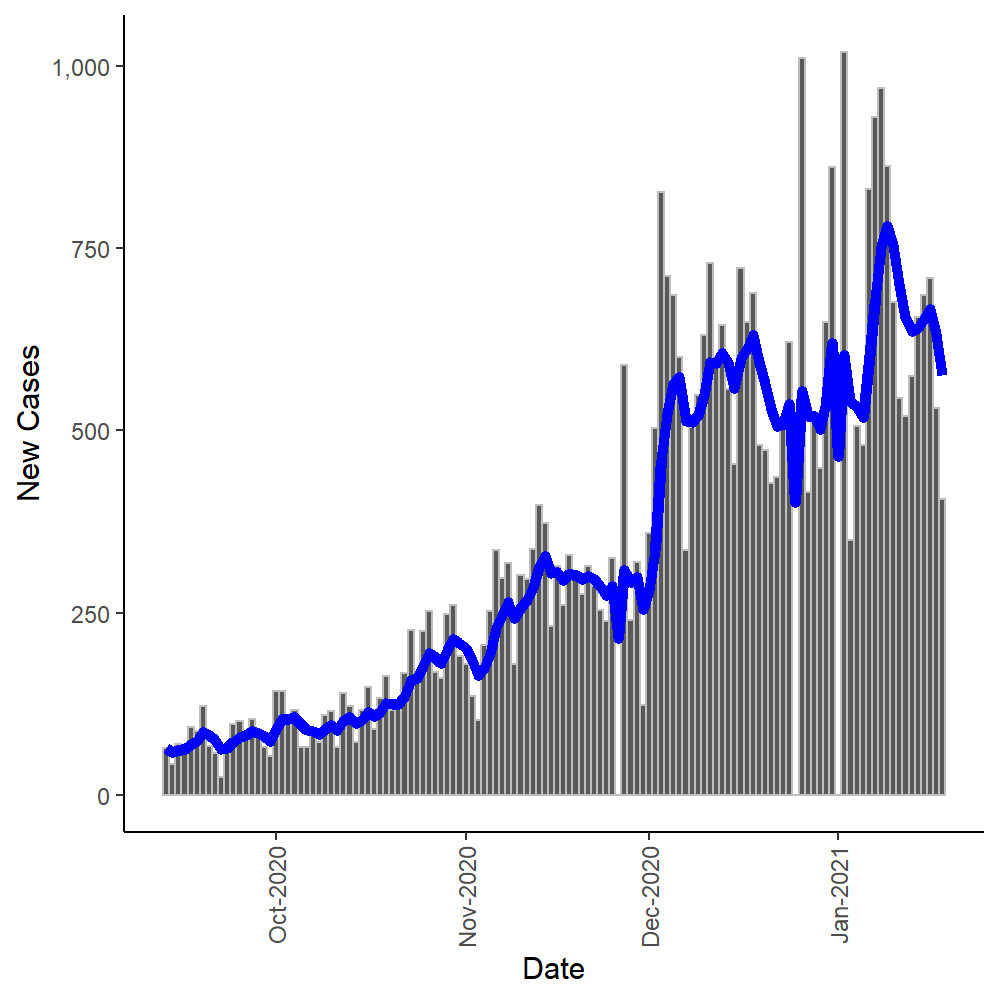

### Kansas City (Wyandotte County), Kansas

#### 7-day moving average of new cases in Kansas City (Wyandotte County), Kansas (2020-03-12 to 2021-01-18)

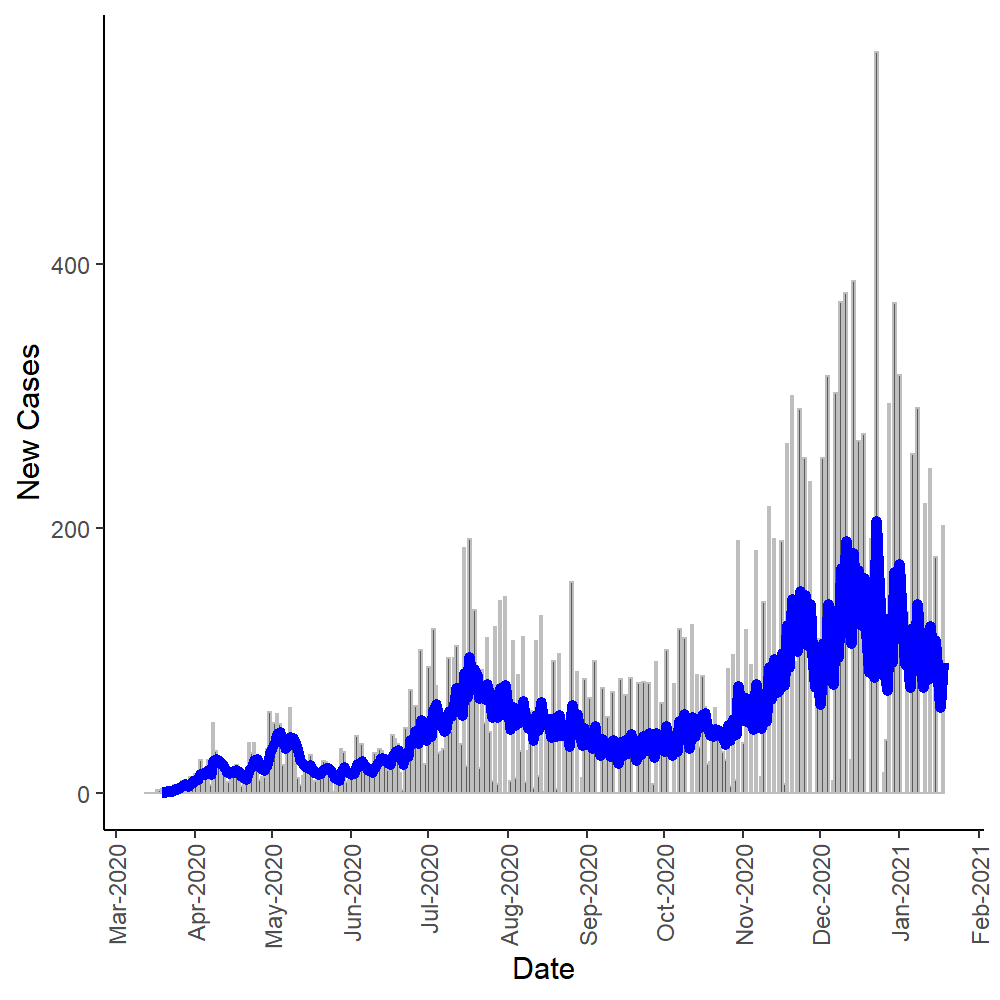

### Hong Kong

> As of yesterday, there has been a total of 9,664 cases of COVID-19 in Hong Kong, China. This is a change of 107 (1.12%) new cases since the day prior. The 7 day moving average is currently 61.07 new cases which is a 33.46% change since the day prior and 47.87% change since the week prior. The immediate trend is heading upward. Based on the addition of yesterday’s data, yesterday was not an inflection point (days since last inflection point: 2 –> 2021-01-17).

#### 7-day moving average of new cases in Hong Kong (2020-01-22 to 2021-01-18)

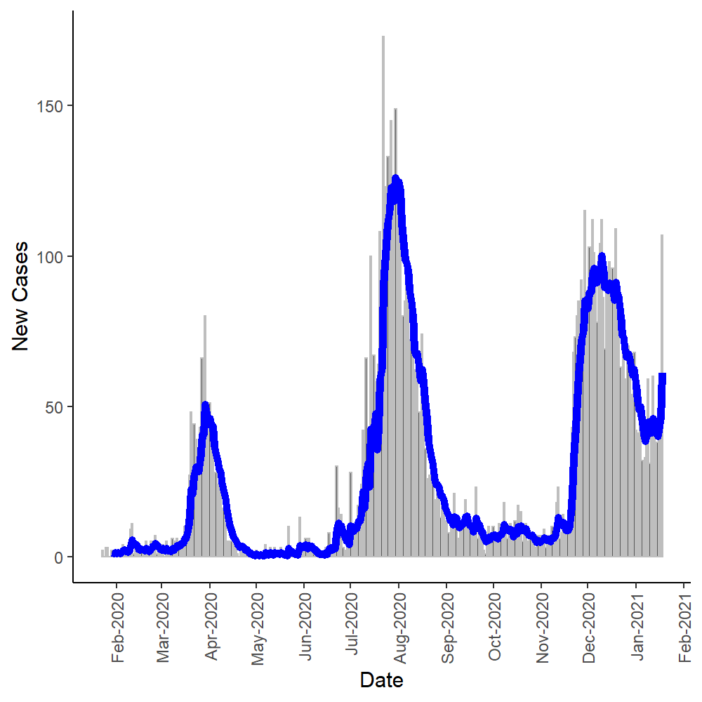

### Ontario, Canada

> As of yesterday, there has been a total of 244,883 cases of COVID-19 in Ontario, Canada. This is a change of 2,544 (1.05%) new cases since the day prior. The 7 day moving average is currently 3,031 new cases which is a -5.08% change since the day prior and -14.98% change since the week prior. The immediate trend is heading downward. Based on the addition of yesterday’s data, yesterday was not an inflection point (days since last inflection point: 4 –> 2021-01-15).

#### 7-day moving average of new cases in Ontario, Canada (2020-01-22 to 2021-01-18)

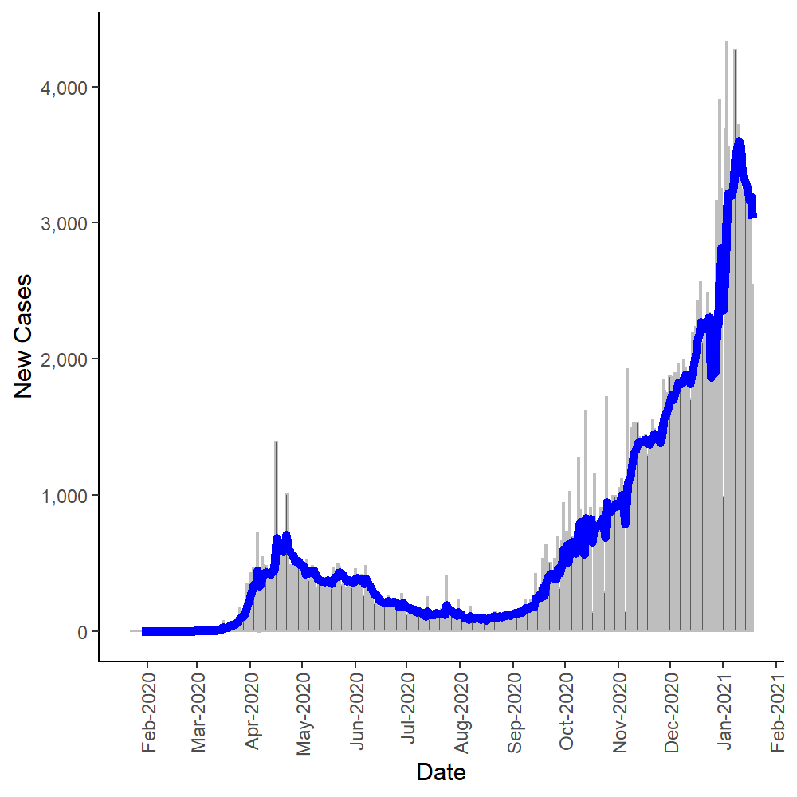